# Nicotine Lozenges

A 2002 study looked at whether nicotine lozenges could help smokers who want to quit. The subjects were randomly assigned to two treatment groups. One group got a nicotine lozenge to take when they had cravings, while the other group got a placebo lozenge. Of the 459 subjects who got the nicotine lozenge, 82 successfully abstained from smoking, while only 44 out of the 458 subjects in the placebo did.

1. Make a 2-way table to show the results of this experiment.

   ```r
   results <- matrix(c(82, 44, 377, 414), nrow = 2, byrow = TRUE)
   colnames(results) = c("Nicotine lozenge", "Placebo")
   rownames(results) = c("Abstained", "Didn't")
   results
   ```

   ```
   ##           Nicotine lozenge Placebo
   ## Abstained               82      44
   ## Didn't                 377     414
   ```

2. Make a stacked bar graph that shows the column percentages for the 2-way table.

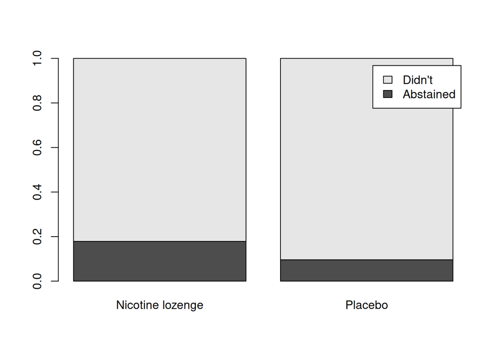

   ```r
   column.percents = prop.table(results, margin = 2) # margin = 1 would be for row percentages
   barplot(column.percents, legend.text = TRUE)
   ```

3. What are the correct null and alternative hypotheses for this situation?
   - $H_0: p_1 = p_2$
   - $H_A: p_1 > p_2$
4. Find the p-value and explain what it means about nicotine lozenges.

   ```r
   prop.test(c(82, 44), c(459, 458), alternative = "greater")
   ```

   ```
   ##
   ##  2-sample test for equality of proportions with continuity correction
   ##
   ## data:  c(82, 44) out of c(459, 458)
   ## X-squared = 12.502, df = 1, p-value = 0.0002032
   ## alternative hypothesis: greater
   ## 95 percent confidence interval:
   ##  0.04327821 1.00000000
   ## sample estimates:
   ##     prop 1     prop 2
   ## 0.17864924 0.09606987
   ```

   The p-value is 0.0002032, which is very strong evidence that nicotine lozenges work better than a placebo to help people quit smoking.
5. In the sample, how many times more likely were people in the nicotine lozenge group to quit smoking than people in the placebo group?

   The two sample proportions were $\hat{p}_1 = 17.9$% and $\hat{p}_2 = 9.6$%. Therefore people taking the nicotine lozenge were $17.9 \, / \, 9.6 = 1.86$ times more likely to quit smoking.
6. What are we 95% confident will be in the confidence interval?

   The confidence interval above is only for the 1-sided alternative where we assumed that nicotine lozenges would definitely not hurt peoples chances to quit smoking. If we remove that assumption, we get a 2-sided confidence interval:

   ```r
   prop.test(c(82, 44), c(459, 458))
   ```

   ```
   ##
   ##  2-sample test for equality of proportions with continuity correction
   ##
   ## data:  c(82, 44) out of c(459, 458)
   ## X-squared = 12.502, df = 1, p-value = 0.0004064
   ## alternative hypothesis: two.sided
   ## 95 percent confidence interval:
   ##  0.03616698 0.12899176
   ## sample estimates:
   ##     prop 1     prop 2
   ## 0.17864924 0.09606987
   ```

   Looking at the R output for the confidence interval, we are 95% confident that nicotine lozenges increase the percent of smokers who can quit by between 3.6% and 12.9%.